# BACS_HW_Week12_106071041

106071041

2021/5/16

# **Question 1 | Deal with nonlinearity**

```r
car <- read.table("auto-data.txt", header = F, na.strings = "?")
names(car) <- c("mpg", "cylinders", "displacement", "horsepower", "weight", "acceleration", "model_year", "origin", "car_name")
```

```r
cars_log <- with(car, data.frame(log(mpg), log(cylinders), log(displacement), log(horsepower), log(weight), log(acceleration), model_year, origin))
```

## a. Run a new regression on the `cars_log` dataset, with `mpg.log.` dependent on all other variables

```r
reg_log <- with(cars_log,lm(log.mpg. ~ log.cylinders.+log.displacement.+log.horsepower.+log.weight.+log.acceleration.+model_year+factor(origin)))
```

```r
summary(reg_log)
```

```
##
## Call:
## lm(formula = log.mpg. ~ log.cylinders. + log.displacement. +
##     log.horsepower. + log.weight. + log.acceleration. + model_year +
##     factor(origin))
##
## Residuals:
##      Min       1Q   Median       3Q      Max
## -0.39727 -0.06880  0.00450  0.06356  0.38542
##
## Coefficients:
##                    Estimate Std. Error t value Pr(>|t|)
## (Intercept)        7.301938   0.361777  20.184  < 2e-16 ***
## log.cylinders.    -0.081915   0.061116  -1.340  0.18094
## log.displacement.  0.020387   0.058369   0.349  0.72707
## log.horsepower.   -0.284751   0.057945  -4.914 1.32e-06 ***
## log.weight.       -0.592955   0.085165  -6.962 1.46e-11 ***
## log.acceleration. -0.169673   0.059649  -2.845  0.00469 **
## model_year         0.030239   0.001771  17.078  < 2e-16 ***
## factor(origin)2    0.050717   0.020920   2.424  0.01580 *
## factor(origin)3    0.047215   0.020622   2.290  0.02259 *
## ---
## Signif. codes:  0 '***' 0.001 '**' 0.01 '*' 0.05 '.' 0.1 ' ' 1
##
## Residual standard error: 0.113 on 383 degrees of freedom
##   (6 observations deleted due to missingness)
## Multiple R-squared:  0.8919, Adjusted R-squared:  0.8897
## F-statistic:   395 on 8 and 383 DF,  p-value: < 2.2e-16
```

### ii. new factors now have effects on mpg? Why?

horsepower, acceleration.  
It may because after log transformation, the relationship between all factors and mpg becomes more linear, the effect of factors have been amplified. In this case, the two factors do have influence on mpg then the correlation will be more obvious after log transformation which is obscure before transformation.

### iii. still insignificant or opposite? Why?

cylinders still insignificant. weight still opposite.  
It may because after log transformation, the relationship between all factors and mpg becomes more linear, the effect of factors have been amplified. In this case, cylinders should be indeed insignificant so that after transformation it stayed insignificant. weight was significantly opposite to mpg so after transformation it got a more negative correlation with mpg with significance.

## b. Take a closer look at weight

### i. `regr_wt` of `mpg` on `weight` from `cars`

```r
regr_wt <- with(car, lm(mpg ~ weight))
```

### ii. `regr_wt_log` of `log.mpg.` on `log.weight.` from `cars_log`

```r
regr_wt_log <- with(cars_log, lm(log.mpg. ~ log.weight.))
```

### v. Interpret the slope of log.weight. vs log.mpg. in simple words

1% change in weight leads to -1.05% change in Y.

```r
with(cars_log, lm(log.mpg. ~ log.weight.))
```

```
##
## Call:
## lm(formula = log.mpg. ~ log.weight.)
##
## Coefficients:
## (Intercept)  log.weight.
##      11.522       -1.058
```

## c. the 95% confidence interval of the slope of `log.weight.` vs. `log.mpg.`

### i. Create a bootstrapped confidence interval

```r
boot_regr <- function(model, dataset){
  boot_index <- sample(1:nrow(dataset), replace=TRUE)
  data_boot <- dataset[boot_index,]
  regr_boot <- lm(model, data=data_boot)
  regr_boot$coefficients
}
```

```r
# Bootstrapping for confidence Interval
coeffs <- replicate(300, boot_regr(log(mpg) ~ log(weight), car))
```

```r
head(coeffs["log(weight)",])
```

```
## [1] -1.065648 -1.013491 -1.051158 -1.030257 -1.110664 -1.077718
```

```r
quantile(coeffs["log(weight)",], c(0.025, 0.975))
```

```
##      2.5%     97.5%
## -1.113823 -1.002868
```

### ii. Verify your results with a confidence interval using traditional statistics

```r
confint(with(car, lm(log(mpg) ~ log(weight))))
```

```
##                 2.5 %    97.5 %
## (Intercept) 11.060154 11.983659
## log(weight) -1.116264 -1.000272
```

# **Question 2 | Tackle multicollinearity**

```r
regr_log <- lm(log.mpg. ~ log.cylinders.+log.displacement.+log.horsepower.+log.weight.+log.acceleration.+model_year +factor(origin),  data=cars_log) ; summary(.Last.value)
```

[output not shown]

## a. Using regression and R2, compute the VIF of `log.weight.`

```r
weight_regr <- lm(log.weight. ~ log.cylinders.+log.displacement.+log.horsepower.+log.acceleration.+model_year +factor(origin),  data=cars_log)
```

```r
r2_weight <- summary(weight_regr)$r.squared
```

```r
vif_weight <- 1 / (1 - r2_weight)
```

```r
sqrt(vif_weight)
```

```
## [1] 4.192269
```

## b. Stepwise VIF Selection

### i. Use `vif(regr_log)` to compute VIF of the all the independent variables

```r
vif(regr_log)[,3]
```

```
##    log.cylinders. log.displacement.   log.horsepower.       log.weight.
##          3.233688          5.442952          3.483110          4.192269
## log.acceleration.        model_year    factor(origin)
##          1.889539          1.141814          1.276702
```

### ii. Eliminate from your model the single independent variable with the largest VIF score that is also greater than 5

```r
regr_log <- lm(log.mpg. ~ log.cylinders.+log.horsepower.+log.weight.+log.acceleration.+model_year +factor(origin),  data=cars_log)
```

```r
vif(regr_log)[,3]
```

```
##    log.cylinders.   log.horsepower.       log.weight. log.acceleration.
##          2.330903          3.480585          3.352572          1.824272
##        model_year    factor(origin)
##          1.136548          1.173685
```

### iii. Repeat steps (i) and (ii) until no more independent variables have VIF scores above 5

Done at ii.

### iv. Report the final regression model and its summary statistics

displacement eliminated:

```r
summary(regr_log)
```

```
##
## Call:
## lm(formula = log.mpg. ~ log.cylinders. + log.horsepower. + log.weight. +
##     log.acceleration. + model_year + factor(origin), data = cars_log)
##
## Residuals:
##      Min       1Q   Median       3Q      Max
## -0.40059 -0.06820  0.00484  0.06208  0.39096
##
## Coefficients:
##                   Estimate Std. Error t value Pr(>|t|)
## (Intercept)        7.26400    0.34469  21.074  < 2e-16 ***
## log.cylinders.    -0.06712    0.04400  -1.525   0.1280
## log.horsepower.   -0.28552    0.05784  -4.937 1.19e-06 ***
## log.weight.       -0.57510    0.06803  -8.454 5.94e-16 ***
## log.acceleration. -0.17510    0.05752  -3.044   0.0025 **
## model_year         0.03018    0.00176  17.143  < 2e-16 ***
## factor(origin)2    0.04717    0.01826   2.582   0.0102 *
## factor(origin)3    0.04394    0.01834   2.396   0.0171 *
## ---
## Signif. codes:  0 '***' 0.001 '**' 0.01 '*' 0.05 '.' 0.1 ' ' 1
##
## Residual standard error: 0.1128 on 384 degrees of freedom
##   (6 observations deleted due to missingness)
## Multiple R-squared:  0.8919, Adjusted R-squared:  0.8899
## F-statistic: 452.5 on 7 and 384 DF,  p-value: < 2.2e-16
```

## c. Have we lost any variables that were previously significant?

No. The only factor eliminated was “displacement” which was already insignificant before the elimination.

## d. From only the formula for VIF, try deducing/deriving the following:

### i. If an independent variable has no correlation with other independent variables, what would its VIF score be?

If one has no correlation with other ones, the denominator will be one, then VIF will be 1 in this case.
$$VIFj = 1 / (1 - R_j^2)$$

### ii. How correlated would X1 and X2 have to be, to get VIF scores of 5 or higher? To get VIF scores of 10 or higher?

1. VIF will be higher than 5 when the denominator less the 1/5: squred R has to be higher than 0.8, R has to be **higher than root of 0.8, which is 0.8944272**.
2. VIF will be higher than 5 when the denominator less the 1/10: squred R has to be higher than 0.9, R has to be **higher than root of 0.9, which is 0.9486833**.

# **Question 3 | Might the relationship of weight on mpg be different for cars from different origins?**

## a. Let’s add three separate regression lines on the scatterplot

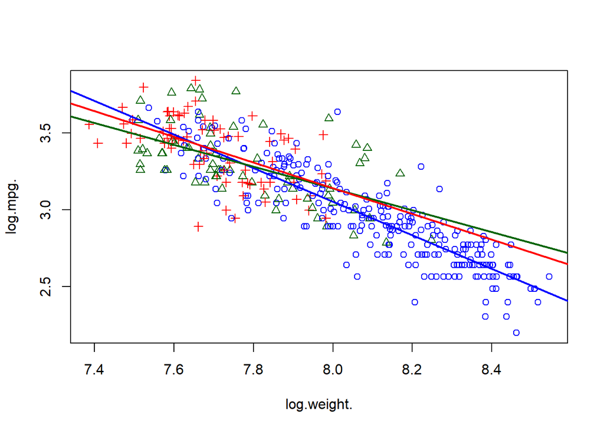

```r
origin_colors = c("blue", "darkgreen", "red")
with(cars_log, plot(log.weight., log.mpg., pch=origin, col=origin_colors[origin]))
cars_us <- subset(cars_log, origin==1)
wt_regr_us <- lm(log.mpg. ~ log.weight., data=cars_us)
cars_euro <- subset(cars_log, origin==2)
wt_regr_euro <- lm(log.mpg. ~ log.weight., data=cars_euro)
cars_japan <- subset(cars_log, origin==3)
wt_regr_japan <- lm(log.mpg. ~ log.weight., data=cars_japan)
abline(wt_regr_us, col=origin_colors[1], lwd=2)
abline(wt_regr_euro, col=origin_colors[2], lwd=2)
abline(wt_regr_japan, col=origin_colors[3], lwd=2)
```